# CASA0005 Week 02 Homework：华盛顿州 Science 县级比较

Washington 2018–19 Science 的县级人数加权比较：达标人数合计 ÷ 应考人数合计 × 100，再与相同完整学校记录构成的州样本基准比较。

主分析限定 `School`、`All` / `All Students`、`All Grades`、`Science`，保留 WCAS 和 AIM 两类测试；学校、学区、州记录不重复相加，`All Grades` 不再与单年级行相加。项目为课程 `casa0005.Rproj`。

Knit 从头计算普通分析块；安装、下载和导出独立执行。

## 结果摘要

39 个县全部匹配。完整公开学校记录的加权州基准为 47.47%；17 县高于、22 县低于该基准。2,904 条学校×测试记录中使用 1,566 条，排除 1,338 条，结果代表完整公开记录样本。

## 环境

```r
helper <- c("tutorial-tools.R", "../tutorial-tools.R") # 分别兼容项目根目录和 week02 工作目录
helper <- helper[file.exists(helper)] # 只留下实际存在的工具文件
if (!length(helper)) stop("请先打开课程 casa0005.Rproj。", call. = FALSE) # 找不到就停，不猜路径
source(helper[[1]]) # 载入共用的路径、包、字段检查函数
root <- gis_root() # 定位有 casa0005.Rproj 的课程根目录
gis_packages(c("tidyverse", "sf", "tmap", "jsonlite", "ragg")) # 确认所需包均可使用
```

```r
library(tidyverse) # 加载 readr、dplyr、tidyr、ggplot2 等
library(sf) # 读取和处理带 geometry 的矢量数据
library(tmap) # 制作地图
stopifnot(packageVersion("tmap") >= "4.0.0", packageVersion("dplyr") >= "1.1.1") # 本机所用 tmap 4 与一对一连接检查所需最低版本
```

## 输入与版本适配

使用成绩 CSV、Washington 县边界 GeoJSON 和官方字段字典。旧 `count_met_standard` 对应当前 `count_consistent_grade_level`；本题分母为 `count_of_students_expected`，不使用实考人数 `count_of_students_tested`。2026 更新后的现成百分比已回算为 tested 分母，不能直接代替题目要求。

字段字典的 `field_dictionary$name` 是字段显示名，根级 `metadata$name` 是数据集标题；`fieldName` 对应 CSV 列名。

```r
assessment_file <- gis_file("data/raw/washington2018/assessment/report_card_assessment_2018_19_republished_20261014.csv") # 已下载成绩
county_file <- gis_file("data/raw/washington2018/boundaries/washington_counties_natural_shoreline.geojson") # 已下载县边界
dictionary_file <- gis_file("data/raw/washington2018/documentation/official_dataset_metadata.json") # 当前版元数据
metadata <- jsonlite::fromJSON(dictionary_file) # JSON 转成 R 列表，里面有字段定义
field_dictionary <- metadata$columns %>% # 取出官方列信息
  dplyr::select(fieldName, name, description) # 保留机器字段名、显示名称和说明
field_dictionary # 查看人数列和 DAT 列的含义
```

```
##                                                                            fieldName
## 1                                                                         schoolyear
## 2                                                                  organizationlevel
## 3                                                                             county
## 4                                                                            esdname
## 5                                                                  esdorganizationid
## 6                                                                       districtcode
## 7                                                                       districtname
## 8                                                             districtorganizationid
## 9                                                                         schoolcode
## 10                                                                        schoolname
## 11                                                              schoolorganizationid
## 12                                                                 currentschooltype
## 13                                                                  studentgrouptype
## 14                                                                      studentgroup
## 15                                                                        gradelevel
## 16                                                         test_administration_group
## 17                                                                testadministration
## 18                                                                       testsubject
## 19                                                                               dat
## 20                                                        count_of_students_expected
## 21                                                          count_of_students_tested
## 22                                                      count_consistent_grade_level
## 23                                                          percent_consistent_grade
## 24   dat_for_consistent_grade_level_knowledge_and_above_including_previously_passed_
## 25                                                          count_foundational_grade
## 26                                                        percent_foundational_grade
## 27 dat_for_foundational_grade_level_knowledge_and_above_including_previously_passed_
## 28                                                           percentlevel1_including
## 29                                                           percentlevel2_including
## 30                                                           percentlevel3_including
## 31                                                           percentlevel4_including
## 32                                                                  percent_no_score
## 33                                                             percent_participation
## 34                                                        percent_taking_alternative
## 35                                                                          dataasof
##                                                                                  name
## 1                                                                          SchoolYear
## 2                                                                   OrganizationLevel
## 3                                                                              County
```

[output cut: 53 more lines]

```
## 21
## 22
## 23
## 24   The disclosure avoidance technique (DAT) applied to the "Consistent Grade Level Knowledge and Above (including previously passed)" column.
## 25
## 26
## 27 The disclosure avoidance technique (DAT) applied to the "Foundational Grade Level Knowledge and Above (including previously passed)" column.
## 28
## 29
## 30
## 31
## 32
## 33
## 34
## 35
```

### 完整读取

先按文字读取全表，保留代码前导零和抑制标记；人数随后显式转换。

```r
report <- readr::read_csv(assessment_file, col_types = readr::cols(.default = readr::col_character()), na = c("", "NULL", "NA")) # 完整读取，空白保留为 NA
required <- c("schoolyear", "organizationlevel", "county", "schoolorganizationid", "studentgrouptype", "studentgroup", "gradelevel", "testsubject", "testadministration", "test_administration_group", "count_of_students_expected", "count_of_students_tested", "count_consistent_grade_level", "dat", "dat_for_consistent_grade_level_knowledge_and_above_including_previously_passed_") # 本版分析所需字段
gis_columns(report, required) # 缺列就停止，避免套用到不同版本
readr::problems(report) # 应是空的解析问题表；有问题先检查再继续
```

```
## # A tibble: 0 × 5
## # ℹ 5 variables: row <int>, col <int>, expected <chr>, actual <chr>, file <chr>
```

```r
dim(report)
```

```
## [1] 755448     35
```

```r
dplyr::glimpse(report) # 简要查看每列的数据类型和样例
```

```
## Rows: 755,448
## Columns: 35
## $ schoolyear                                                                        <chr> …
## $ organizationlevel                                                                 <chr> …
## $ county                                                                            <chr> …
## $ esdname                                                                           <chr> …
## $ esdorganizationid                                                                 <chr> …
## $ districtcode                                                                      <chr> …
## $ districtname                                                                      <chr> …
## $ districtorganizationid                                                            <chr> …
## $ schoolcode                                                                        <chr> …
## $ schoolname                                                                        <chr> …
## $ schoolorganizationid                                                              <chr> …
## $ currentschooltype                                                                 <chr> …
## $ studentgrouptype                                                                  <chr> …
```

[output cut: 22 more lines]

```r
report %>% dplyr::count(schoolyear, organizationlevel) # 看有哪些学年与统计层级
```

```
## # A tibble: 3 × 3
##   schoolyear organizationlevel      n
##   <chr>      <chr>              <int>
## 1 2018-19    District          167833
## 2 2018-19    School            586529
## 3 2018-19    State               1086
```

## 记录层级与唯一键

主分析唯一键为“学校 × 测试”，不是单独学校代码。州记录留作独立核对，不进入学校人数求和。

```r
report %>% dplyr::filter(testsubject == "Science") %>% dplyr::count(studentgrouptype, studentgroup, sort = TRUE) # 看 Science 学生群体标签
```

```
## # A tibble: 28 × 3
##    studentgrouptype studentgroup                      n
##    <chr>            <chr>                         <int>
##  1 All              All Students                   7963
##  2 homeless         Non-Homeless                   7948
##  3 s504             Non Section 504                7946
##  4 Foster           Non-Foster Care                7941
##  5 Migrant          Non Migrant                    7936
##  6 ELL              Non-English Language Learners  7812
##  7 Gender           Male                           7599
##  8 SWD              Students with Disabilities     7445
##  9 Race             White                          7285
## 10 FRL              Low-Income                     7220
## # ℹ 18 more rows
```

```r
science <- report %>% # 从完整成绩表开始
  dplyr::filter(schoolyear == "2018-19", testsubject == "Science", studentgrouptype == "All", studentgroup == "All Students", gradelevel == "All Grades") # 固定学年、科目、总群体和全年级
science %>% dplyr::count(organizationlevel, testadministration, test_administration_group) # 检查层级和两种测试，没有把不同层级加总
```

```
## # A tibble: 6 × 4
##   organizationlevel testadministration test_administration_group     n
##   <chr>             <chr>              <chr>                     <int>
## 1 District          AIM                AIM                         174
## 2 District          WCAS               WCAS                        299
## 3 School            AIM                AIM                         734
## 4 School            WCAS               WCAS                       2170
## 5 State             AIM                AIM                           1
## 6 State             WCAS               WCAS                          1
```

```r
schools <- science %>% # 学校行用于县级统计
  dplyr::filter(organizationlevel == "School", !is.na(county), county != "Multiple", testadministration %in% c("WCAS", "AIM")) # 排除非县级名称；两种 Science 测试均保留
stopifnot(nrow(schools) > 0L, all(schools$testadministration == schools$test_administration_group)) # 防止空筛选或版本中的测试标签冲突
school_keys <- schools %>% dplyr::count(schoolorganizationid, testadministration)
stopifnot(!anyNA(schools$schoolorganizationid), all(school_keys$n == 1L)) # 重复时不能 distinct() 随便删；应回看筛选口径
schools %>% dplyr::count(testadministration, dat, sort = TRUE) # 保留 DAT 状态检查
```

```
## # A tibble: 10 × 3
##    testadministration dat                    n
##    <chr>              <chr>              <int>
##  1 WCAS               None                1563
##  2 AIM                N<10                 698
##  3 WCAS               N<10                 152
##  4 WCAS               Top/Bottom           130
##  5 WCAS               Cross Grade          126
##  6 WCAS               No Students          112
##  7 WCAS               Cross Organization    87
##  8 AIM                Top/Bottom            19
##  9 AIM                No Students           14
## 10 AIM                None                   3
```

## DAT 与完整人数对

仅纯整数文本可转换为人数，不从 `<10` 抽取 10。`usable` 要求 general DAT 为 `None`，且分子、分母同时完整；专门 DAT 列显示 `No DAT` 不单独保证人数完整。缺失或保密人数不填零，不分别忽略缺失后累加两个不同集合。

```r
strict_count <- function(x) { # 定义只接受非负整数文本的转换函数
  out <- rep(NA_real_, length(x)) # 先建立与输入等长的缺失数值向量
  ok <- !is.na(x) & grepl("^[0-9]+$", x) # 只有由数字组成的字符串才允许转换
  out[ok] <- as.numeric(x[ok]) # 把允许的部分转成数值，其余仍是 NA
  out # 函数返回整个向量
}
schools <- schools %>% # 保留原始文本列，同时新增分析列
  dplyr::mutate(expected = strict_count(count_of_students_expected), met = strict_count(count_consistent_grade_level), county_key = stringr::str_to_upper(stringr::str_squish(county))) # 标准化县名空格和大小写
schools %>% dplyr::count(dat, dat_for_consistent_grade_level_knowledge_and_above_including_previously_passed_, sort = TRUE) # 查看保密状态，不能把隐藏值当作零
```

```
## # A tibble: 7 × 3
##   dat                dat_for_consistent_grade_level_knowledge_and_above_…¹     n
##   <chr>              <chr>                                                 <int>
## 1 None               No DAT                                                 1566
## 2 N<10               N<10                                                    850
## 3 Cross Grade        No DAT                                                  126
## 4 No Students        No Students                                             126
## 5 Cross Organization No DAT                                                   87
## 6 Top/Bottom         No DAT                                                   81
## 7 Top/Bottom         Top/Bottom                                               68
## # ℹ abbreviated name:
## #   ¹dat_for_consistent_grade_level_knowledge_and_above_including_previously_passed_
```

```r
schools <- schools %>% # 增加完整对标志，稍后用同一批记录的分子分母
  dplyr::mutate(usable = !is.na(dat) & dat == "None" & !is.na(expected) & !is.na(met) & expected > 0 & met >= 0 & met <= expected) # general DAT 未遮蔽，应考正数，达标人数不超过应考
schools %>% dplyr::count(testadministration, usable) # 统计两类测试各有多少可使用行
```

```
## # A tibble: 4 × 3
##   testadministration usable     n
##   <chr>              <lgl>  <int>
## 1 AIM                FALSE    731
## 2 AIM                TRUE       3
## 3 WCAS               FALSE    607
## 4 WCAS               TRUE    1563
```

## 县级加权汇总

沿用参考代码的完整记录法：先排除缺失人数对，再按总达标人数除以总应考人数。记录排除比例不是学生排除比例；已知应考人数仍不包括本身被隐藏的计数。主图对应完整公开学校测试记录样本，不宣称为全体学生的精确县率。

```r
coverage <- schools %>% # 先看各县输入和排除情况
  dplyr::group_by(county_key) %>% # 每个县单独汇总
  dplyr::summarise(n_records = dplyr::n(), n_used = sum(usable), n_excluded = sum(!usable), known_expected_all = sum(expected, na.rm = TRUE), known_expected_used = sum(expected[usable]), .groups = "drop") # known 是已公开人数，不是完整真实总人数
county_only <- schools %>% # 主分析只使用完整人数对
  dplyr::filter(usable) %>% # 同时保留分子分母，去掉不完整记录
  dplyr::group_by(county_key) %>% # 按县分组
  dplyr::summarise(total_county_met_standard = sum(met), total_county_to_test = sum(expected), .groups = "drop") %>% # 两个和来自同一批记录
  dplyr::mutate(percent_met_per_county = 100 * total_county_met_standard / total_county_to_test) # 计算 0–100 的百分比
county_only <- coverage %>% dplyr::left_join(county_only, by = "county_key", relationship = "one-to-one") # 保留没有可用人数对的县，其率为 NA
gis_unique(county_only, "county_key") # 确认一县一行
county_only %>% dplyr::arrange(dplyr::desc(n_excluded)) # 查看缺失最多的县与记录数
```

```
## # A tibble: 39 × 9
##    county_key n_records n_used n_excluded known_expected_all known_expected_used
##    <chr>          <int>  <int>      <int>              <dbl>               <dbl>
##  1 KING             652    396        256              57511               57511
##  2 PIERCE           333    192        141              27013               27013
##  3 SNOHOMISH        253    139        114              21361               21361
##  4 SPOKANE          221    120        101              14882               14882
##  5 CLARK            172    102         70              16955               16955
##  6 YAKIMA           131     61         70               9756                9756
##  7 KITSAP            94     53         41               7581                7581
##  8 THURSTON         108     68         40               8689                8689
##  9 WHATCOM           85     45         40               4804                4804
## 10 GRANT             65     29         36               3533                3533
## # ℹ 29 more rows
## # ℹ 3 more variables: total_county_met_standard <dbl>,
## #   total_county_to_test <dbl>, percent_met_per_county <dbl>
```

## 样本州基准与县差值

基准来自相同完整学校记录的全州人数合计，不对学校率或县率作简单平均。县率减州基准的差值以百分点计，分类前保留原精度；`1e-8` 仅作浮点容差。

```r
stopifnot(sum(county_only$total_county_to_test, na.rm = TRUE) > 0) # 没有可用人数就不能计算州基准
state_average <- 100 * sum(county_only$total_county_met_standard, na.rm = TRUE) / sum(county_only$total_county_to_test, na.rm = TRUE) # 汇总已纳入记录的州加权基准
county_comparison <- county_only %>% # 在每县一行的表上增加比较列
  dplyr::mutate(difference_to_state = percent_met_per_county - state_average, above_below = dplyr::case_when(is.na(difference_to_state) ~ "无完整公开人数对", difference_to_state > 1e-8 ~ "高于样本州基准", difference_to_state < -1e-8 ~ "低于样本州基准", TRUE ~ "与样本州基准相同")) # 差值单位为百分点，不是百分比变化
state_average # 样本州基准
```

```
## [1] 47.46616
```

```r
county_comparison %>% dplyr::arrange(dplyr::desc(difference_to_state)) # 从高到低查看县级差值
```

```
## # A tibble: 39 × 11
##    county_key n_records n_used n_excluded known_expected_all known_expected_used
##    <chr>          <int>  <int>      <int>              <dbl>               <dbl>
##  1 WHITMAN           30     10         20                798                 798
##  2 LINCOLN           15      8          7                422                 422
##  3 ISLAND            19      5         14                710                 710
##  4 GARFIELD           3      2          1                 68                  68
##  5 KITSAP            94     53         41               7581                7581
##  6 ASOTIN            13      5          8                304                 304
##  7 THURSTON         108     68         40               8689                8689
##  8 KING             652    396        256              57511               57511
##  9 COLUMBIA           6      1          5                 27                  27
## 10 PEND OREI…        12      2         10                189                 189
## # ℹ 29 more rows
## # ℹ 5 more variables: total_county_met_standard <dbl>,
## #   total_county_to_test <dbl>, percent_met_per_county <dbl>,
## #   difference_to_state <dbl>, above_below <chr>
```

### 官方 State 行核对

官方州汇总可能保有学校公开行中的隐藏人数，属于独立口径，不替换主图基准，也不用于反推学校隐私计数。

```r
official_state <- science %>% # 从同一学年、科目、总群体、全年级的数据取州级行
  dplyr::filter(organizationlevel == "State", testadministration %in% c("WCAS", "AIM")) %>% # 只取全州两种 Science 测试
  dplyr::mutate(expected = strict_count(count_of_students_expected), met = strict_count(count_consistent_grade_level)) # 使用相同人数转换
stopifnot(nrow(official_state) == 2L, all(official_state$dat == "None"), !anyDuplicated(official_state$testadministration), all(is.finite(official_state$expected)), all(is.finite(official_state$met)), all(official_state$expected > 0), all(official_state$met <= official_state$expected)) # 保证可比较且不重复
official_state_rate <- 100 * sum(official_state$met) / sum(official_state$expected) # 官方全州行重算的同分母率
tibble(basis = c("完整公开学校记录样本", "官方 State All Grades 行"), percent = c(state_average, official_state_rate)) # 并列展示，保留口径差异
```

```
## # A tibble: 2 × 2
##   basis                    percent
##   <chr>                      <dbl>
## 1 完整公开学校记录样本        47.5
## 2 官方 State All Grades 行    46.5
```

## 县边界与连接

当前字段为 `COUNTYLABEL`，旧 Shapefile 的 `countylabe` 是截短名称。县名统一后双向检查漏接，再作一对一左连接；缺数据的县保留边界。

```r
shape <- sf::st_read(county_file, quiet = TRUE) # 读取县边界；不要把第一周的 shape 对象当成本周输入
gis_columns(shape, "COUNTYLABEL") # 确认当前边界的县名列
stopifnot(nrow(shape) == 39L, !any(sf::st_is_empty(shape))) # Washington 应有 39 个非空县几何
shape <- shape %>% dplyr::mutate(county_key = stringr::str_to_upper(stringr::str_squish(COUNTYLABEL))) # 使用与成绩表相同的县名规则
gis_unique(shape, "county_key") # 一县一个边界；重复就不能继续一对一连接
sf::st_crs(shape) # 看边界坐标参考系；本地文件为经纬度坐标
```

```
## Coordinate Reference System:
##   User input: WGS 84
##   wkt:
## GEOGCRS["WGS 84",
##     DATUM["World Geodetic System 1984",
##         ELLIPSOID["WGS 84",6378137,298.257223563,
##             LENGTHUNIT["metre",1]]],
##     PRIMEM["Greenwich",0,
##         ANGLEUNIT["degree",0.0174532925199433]],
##     CS[ellipsoidal,2],
##         AXIS["geodetic latitude (Lat)",north,
##             ORDER[1],
##             ANGLEUNIT["degree",0.0174532925199433]],
##         AXIS["geodetic longitude (Lon)",east,
##             ORDER[2],
##             ANGLEUNIT["degree",0.0174532925199433]],
##     ID["EPSG",4326]]
```

```r
unmatched_counts <- dplyr::anti_join(county_comparison, sf::st_drop_geometry(shape), by = "county_key") # 有统计但没有边界的县
unmatched_shape <- dplyr::anti_join(sf::st_drop_geometry(shape), county_comparison, by = "county_key") # 有边界但没有学校记录的县
unmatched_counts # 需要检查的第一侧未匹配
```

```
## # A tibble: 0 × 11
## # ℹ 11 variables: county_key <chr>, n_records <int>, n_used <int>,
## #   n_excluded <int>, known_expected_all <dbl>, known_expected_used <dbl>,
## #   total_county_met_standard <dbl>, total_county_to_test <dbl>,
## #   percent_met_per_county <dbl>, difference_to_state <dbl>, above_below <chr>
```

```r
unmatched_shape # 需要检查的第二侧未匹配
```

```
## [1] OBJECTID      COUNTY        CREATIONDATE  EDITDATE      COUNTYLABEL
## [6] Shape__Area   Shape__Length county_key
## <0 rows> (or 0-length row.names)
```

```r
stopifnot(nrow(unmatched_counts) == 0L) # 有无法定位的县先解决拼写/来源问题
```

```r
joined_data <- shape %>% dplyr::left_join(county_comparison, by = "county_key", relationship = "one-to-one") # 左边是边界，保留全部 39 县
stopifnot(nrow(joined_data) == nrow(shape)) # 连接不能增加或丢失边界行
joined_data <- joined_data %>% dplyr::mutate(above_below = tidyr::replace_na(above_below, "无完整公开人数对")) # 未匹配县明确归入无数据类别
sf::st_drop_geometry(joined_data) %>% dplyr::select(COUNTYLABEL, percent_met_per_county, difference_to_state, n_used, n_excluded, above_below) # 核对地图将使用的表
```

```
##     COUNTYLABEL percent_met_per_county difference_to_state n_used n_excluded
## 1  Pend Oreille               50.26455           2.7983875      2         10
## 2       Stevens               40.54545          -6.9207082      9         27
## 3         Ferry               28.00000         -19.4661627      3          7
## 4       Whatcom               49.64613           2.1799655     45         40
## 5      Okanogan               44.25211          -3.2140544     18         24
## 6      San Juan               46.87500          -0.5911627      5          7
## 7        Skagit               44.80166          -2.6645034     32         29
## 8       Clallam               47.05579          -0.4103776     15         19
## 9        Island               60.56338          13.0972175      5         14
## 10      Douglas               38.89239          -8.5737776      7         13
## 11      Spokane               48.52842           1.0622608    120        101
## 12        Grant               33.54090         -13.9252627     29         36
## 13      Lincoln               60.66351          13.1973444      8          7
## 14     Kittitas               47.81086           0.3446954      8         10
```

[output cut: 65 more lines]

## 高于／低于基准地图

类别、配色和缺失值单独编码。`map_font` 为屏幕与 PNG 明确指定中文字体；跨电脑使用需有对应中文字形。地图表示描述差异，不解释学校或政策因果。

```r
tmap::tmap_mode("plot") # 使用可保存的静态地图模式
```

```
## ℹ tmap modes "plot" - "view"
## ℹ toggle with `tmap::ttm()`
```

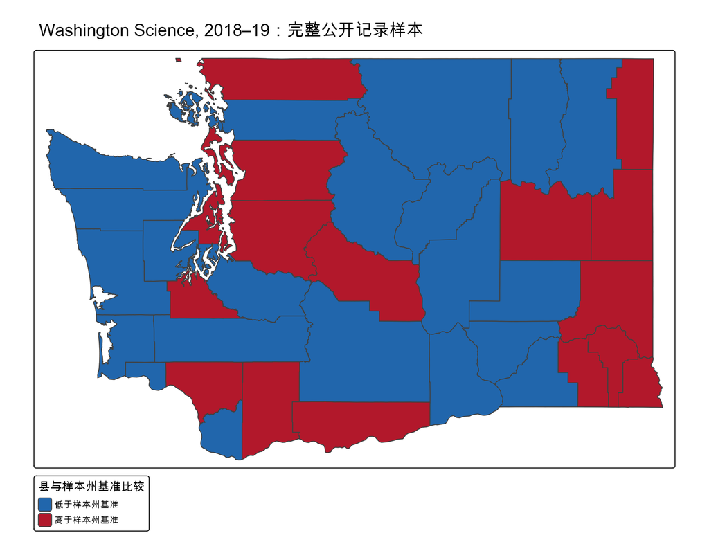

```r
map_font <- "Arial Unicode MS" # 本机已验证可读取并覆盖中文的字体，避免图题和图例显示方框
map_colors <- c("低于样本州基准" = "#2166ac", "高于样本州基准" = "#b2182b", "与样本州基准相同" = "#f7f7f7", "无完整公开人数对" = "#bdbdbd") # 蓝低、红高、灰色缺数据
wa_map <- tmap::tm_shape(joined_data) + # 指定连接后的边界数据
  tmap::tm_polygons(fill = "above_below", fill.scale = tmap::tm_scale_categorical(values = map_colors), fill.legend = tmap::tm_legend(title = "县与样本州基准比较", title.fontfamily = map_font, text.fontfamily = map_font)) + # 用比较类别填色
  tmap::tm_title("Washington Science, 2018–19：完整公开记录样本", fontfamily = map_font) + # 在标题中写清范围并指定中文字体
  tmap::tm_layout(text.fontfamily = map_font) # 图内其他文字使用同一字体
wa_map # 在 Plots 查看；图例和灰色县也需要检查
```

## 可选导出

目标位于 `week02/outputs/`；任一同名目标存在时停止，避免覆盖。PNG 通过 ragg 保存外观，CSV 保存属性，GPKG 保存空间结果；GPKG 不携带 tmap 配色。

```r
csv_out <- gis_new_output("week02", "washington-science-2018-19-my-run.csv") # 新建目标路径，同名时停止
png_out <- gis_new_output("week02", "washington-science-2018-19-my-run.png") # PNG 是图片，不能编辑属性表
gpkg_out <- gis_new_output("week02", "washington-science-2018-19-my-run.gpkg") # GPKG 保留几何和属性，不等于图片样式
readr::write_csv(sf::st_drop_geometry(joined_data), csv_out) # 保存县级表和缺失检查字段
tmap::tmap_save(wa_map, filename = png_out, device = ragg::agg_png, width = 9, height = 7, units = "in", dpi = 180) # 保存地图图片
sf::st_write(joined_data, gpkg_out, layer = "county_science", quiet = TRUE) # 保存空间数据，不删除旧图层
data.frame(file = c(csv_out, png_out, gpkg_out), exists = file.exists(c(csv_out, png_out, gpkg_out))) # 导出后确认三个文件存在
```

## 报告复现

从新 R 会话 Knit 生成 HTML，可选导出仍跳过。报告保留人数口径、DAT 排除覆盖、样本州基准、官方 State 行的独立核对及地图，不把两个口径混写。

## 来源与改编

- [官方第 2 章 Homework](https://andrewmaclachlan.github.io/CASA0005repo/introduction-to-r.html#homework-1)
- [人数计算参考代码](https://github.com/andrewmaclachlan/CASA0005_homework/blob/main/homework_2_file.Rmd)
- [Report Card Assessment School Years 2017-18 and 2018-19](https://data.wa.gov/Education/Report-Card-Assessment-School-Years-2017-18-and-2018-19/6rue-47ak)
- [OSPI 2026 分母与保密处理更新说明](https://data.wa.gov/api/views/6rue-47ak/files/16810f92-591d-4e23-af3f-79b7d6bf02d0?download=true)

中文整理与代码适配使用 AI 辅助；原作者、许可及改编范围见来源与改编范围。